# Лабораторная 5

Дискреционное разграничение прав в Linux. Исследование влияния дополнительных атрибутов

Шалыгин Г. Э.

Российский университет дружбы народов, Москва, Россия

# Информация

## Докладчик

- Шалыгин Георгий Эдуардович
- студент НФИ-02-20
- Российский университет дружбы народов

# Вводная часть

## Актуальность

- - Информационная безопасность - важная часть компетенции в образовательном треке НФИ

## Цели и задачи

- Изучение механизмов изменения идентификаторов, применения SetUID- и Sticky-битов. Получение практических навыков работы в консоли с дополнительными атрибутами. Рассмотрение работы механизма смены идентификатора процессов пользователей, а также влияние бита Sticky на запись и удаление файлов.

## Материалы и методы

- Процессор `pandoc` для входного формата Markdown
- Результирующие форматы
  - `pdf`
  - `html`
- Автоматизация процесса создания: `Makefile`
- Компилятор Julia
- OpenModelica

# Результаты

## UID

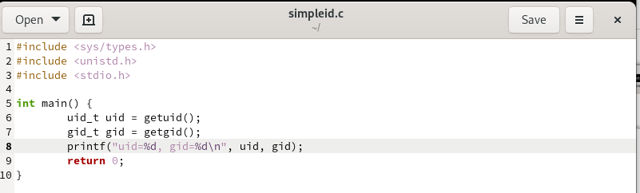

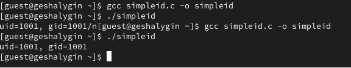

run simpleid

## Реальные идентификаторы

Усложним программу, добавив вывод действительных идентификаторов. Скомпилируем и запустим simpleid2.c

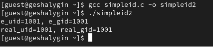

simpleid2

## Добавление uid бита

Запустите simpleid2 и id: ./simpleid2 id

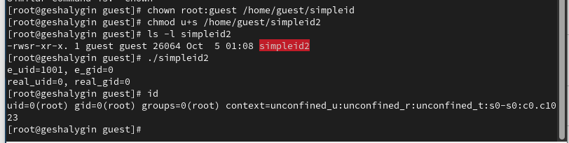

simpleid2 with u+s

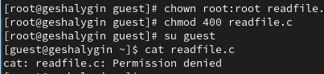

Проверка прав доступа для новых атрибутов

## Результаты run readfile

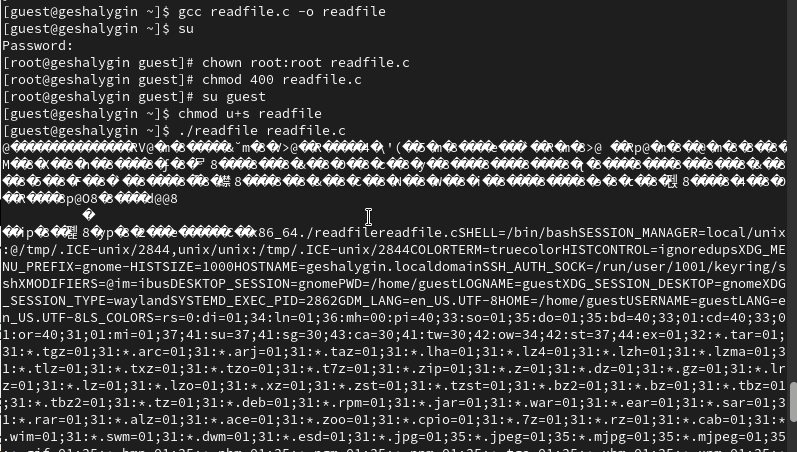

run readfile

## Доступ для пользователя gues2

От имени пользователя guest создадим файл file01.txt в директории /tmp со словом test. Просмотрим атрибуты у только что созданного файла и разрешим чтение и запись для категории пользователей «все остальные».

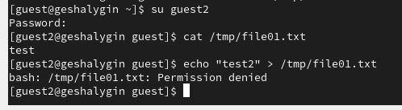

проверка доступа

## guest2

Выполним команду, снимающую sticky-бит.

Теперь дозапись недоступна, удаление доступно.

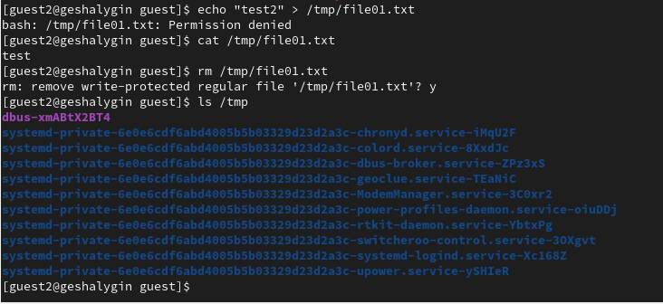

проверка доступа

# Вывод

В результате выполнения работы мы изучили механизмы изменения идентификаторов, применения SetUID- и Sticky-битов. Получили практические навыки работы в консоли с дополнительными атрибутами. Рассмотрели работу механизма смены идентификатора процессов пользователей, а также влияние бита Sticky на запись и удаление файлов.